# Análisis descriptivo del Indicador de Seguimiento a la Economía (ISE), 2005-2026

## 8.2 Regresores de calendario y de la pandemia

Además de la estacionalidad se incluyen:

- **Semana Santa:** la primera diferencia de la proporción de festivos de Semana Santa en el mes (`d_ss`), porque la serie modelada está diferenciada.
- **Pandemia:** variables indicadoras (pulsos) para marzo a julio de 2020. Absorben esas observaciones atípicas para que no distorsionen la estimación de los efectos mensuales.

**Ver código**

```r
datos_mod <- tibble(
  index = yearmonth(as.Date(Fechas_ise[-1])),
  dlog  = as.numeric(dlise),
  d_ss  = diff(ss_nivel)
) |>
  mutate(covid_mar = as.integer(index == yearmonth("2020 Mar")),
         covid_abr = as.integer(index == yearmonth("2020 Apr")),
         covid_may = as.integer(index == yearmonth("2020 May")),
         covid_jun = as.integer(index == yearmonth("2020 Jun")),
         covid_jul = as.integer(index == yearmonth("2020 Jul"))) |>
  as_tsibble(index = index)

datos_mod
```

```
# A tsibble: 257 x 8 [1M]
      index     dlog  d_ss covid_mar covid_abr covid_may covid_jun covid_jul
      <mth>    <dbl> <dbl>     <int>     <int>     <int>     <int>     <int>
 1 2005 Feb  0.0255      0         0         0         0         0         0
 2 2005 Mar  0.0104      1         0         0         0         0         0
 3 2005 Apr  0.0129     -1         0         0         0         0         0
 4 2005 May -0.00434     0         0         0         0         0         0
 5 2005 Jun  0.0129      0         0         0         0         0         0
 6 2005 Jul  0.00776     0         0         0         0         0         0
 7 2005 Aug  0.0203      0         0         0         0         0         0
 8 2005 Sep  0.00834     0         0         0         0         0         0
 9 2005 Oct  0.00199     0         0         0         0         0         0
10 2005 Nov  0.0413      0         0         0         0         0         0
# ℹ 247 more rows
```

## 8.3 Ajuste y comparación de modelos

Se usa `TSLM()` de `fable`, que estima la regresión por mínimos cuadrados. Es equivalente a `ARIMA(y ~ ... + pdq(0, 0, 0) + PDQ(0, 0, 0))` del material de clase: una regresión con errores sin estructura ARMA.

**Ver código**

```r
modelos <- datos_mod |>
  model(
    Fourier_K1 = TSLM(dlog ~ fourier(K = 1)),
    Fourier_K2 = TSLM(dlog ~ fourier(K = 2)),
    Fourier_K3 = TSLM(dlog ~ fourier(K = 3)),
    Fourier_K4 = TSLM(dlog ~ fourier(K = 4)),
    Fourier_K5 = TSLM(dlog ~ fourier(K = 5)),
    Fourier_K6 = TSLM(dlog ~ fourier(K = 6)),
    Dummy      = TSLM(dlog ~ season()),
    Dummy_SS   = TSLM(dlog ~ season() + d_ss),
    Dummy_SS_COVID = TSLM(dlog ~ season() + d_ss +
                            covid_mar + covid_abr + covid_may + covid_jun + covid_jul)
  )

comparacion <- glance(modelos) |>
  select(.model, df, r_squared, adj_r_squared, sigma2, AIC, BIC) |>
  mutate(sigma = sqrt(sigma2)) |>
  select(-sigma2) |>
  arrange(BIC)

comparacion |> mutate(across(where(is.numeric), ~ round(.x, 4)))
```

```
# A tibble: 9 × 7
  .model            df r_squared adj_r_squared    AIC    BIC  sigma
  <chr>          <dbl>     <dbl>         <dbl>  <dbl>  <dbl>  <dbl>
1 Dummy_SS_COVID    18    0.942         0.938  -2131. -2063. 0.0153
2 Dummy_SS          13    0.901         0.896  -2005. -1956. 0.0196
3 Dummy             12    0.884         0.878  -1966. -1920. 0.0213
4 Fourier_K6        12    0.884         0.878  -1966. -1920. 0.0213
5 Fourier_K5        11    0.857         0.851  -1914. -1872. 0.0235
6 Fourier_K4         9    0.620         0.608  -1668. -1632. 0.0382
7 Fourier_K3         7    0.309         0.292  -1518. -1489. 0.0513
8 Fourier_K2         5    0.104         0.0896 -1455. -1433. 0.0582
9 Fourier_K1         3    0.0397        0.0322 -1441. -1427. 0.06
```

**Ver código**

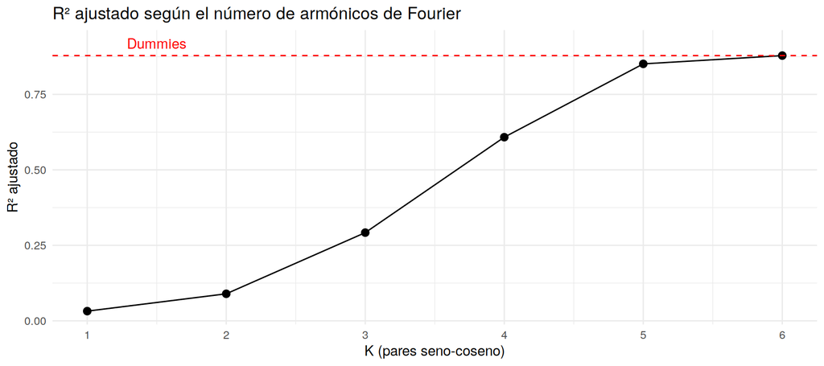

```r
comparacion |>
  filter(str_detect(.model, "Fourier")) |>
  mutate(K = as.integer(str_extract(.model, "\\d"))) |>
  ggplot(aes(K, adj_r_squared)) +
  geom_line() + geom_point(size = 2.5) +
  geom_hline(yintercept = comparacion$adj_r_squared[comparacion$.model == "Dummy"],
             linetype = "dashed", color = "red") +
  annotate("text", x = 1.5, y = comparacion$adj_r_squared[comparacion$.model == "Dummy"] + 0.04,
           label = "Dummies", color = "red") +
  scale_x_continuous(breaks = 1:6) +
  labs(title = "R² ajustado según el número de armónicos de Fourier",
       x = "K (pares seno-coseno)", y = "R² ajustado") +
  theme_minimal()
```

Resultados de la comparación:

- Con uno o dos armónicos el ajuste es muy pobre (R² ajustado menor a 0,10). Como anticipaba el periodograma, el patrón estacional del ISE es demasiado abrupto para una onda suave.
- El ajuste mejora mucho al pasar de $K = 3$ a $K = 5$, y $K = 6$ reproduce exactamente el modelo de dummies (mismo AIC, BIC y R²), como se esperaba por la teoría. En esta serie los términos de Fourier no permiten ahorrar parámetros.
- Agregar el regresor de Semana Santa y los pulsos de la pandemia mejora el ajuste de manera importante y reduce el error estándar residual. **El modelo `Dummy_SS_COVID` es el que tiene menor AIC y BIC.**

## 8.4 Ajustados frente a observados

**Ver código**

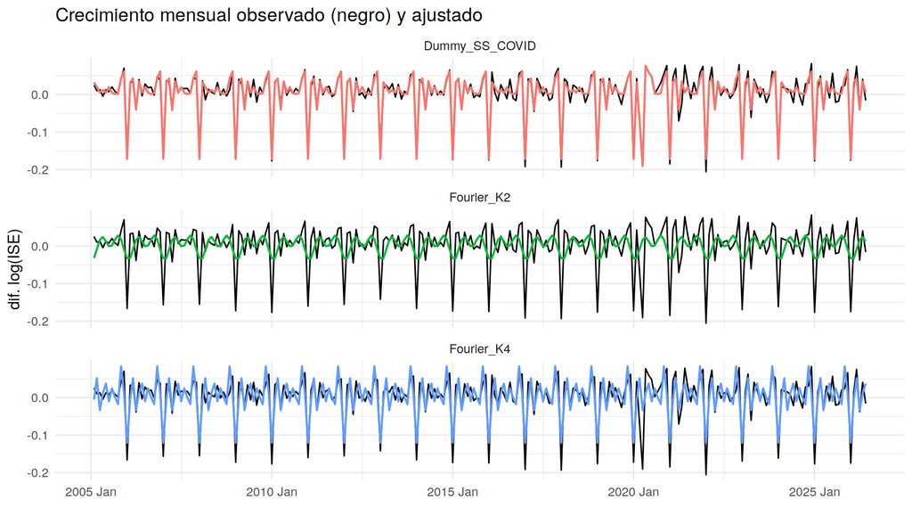

```r
augment(modelos) |>
  filter(.model %in% c("Fourier_K2", "Fourier_K4", "Dummy_SS_COVID")) |>
  ggplot(aes(x = index)) +
  geom_line(aes(y = dlog), color = "black") +
  geom_line(aes(y = .fitted, color = .model), linewidth = 0.7) +
  facet_wrap(~ .model, ncol = 1) +
  labs(title = "Crecimiento mensual observado (negro) y ajustado",
       x = NULL, y = "dif. log(ISE)", color = NULL) +
  theme_minimal() + theme(legend.position = "none")
```

**Ver código**

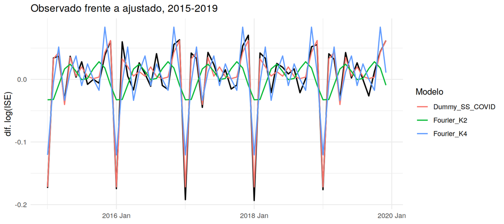

```r
## Acercamiento 2015-2019 para comparar la forma del patrón estacional
augment(modelos) |>
  filter(.model %in% c("Fourier_K2", "Fourier_K4", "Dummy_SS_COVID"),
         index >= yearmonth("2015 Jan"), index <= yearmonth("2019 Dec")) |>
  ggplot(aes(x = index)) +
  geom_line(aes(y = dlog), color = "black", linewidth = 0.8) +
  geom_line(aes(y = .fitted, color = .model), linewidth = 0.7) +
  labs(title = "Observado frente a ajustado, 2015-2019",
       x = NULL, y = "dif. log(ISE)", color = "Modelo") +
  theme_minimal()
```

## 8.5 Efectos estacionales estimados

**Ver código**

```r
modelo_final <- modelos |> select(Dummy_SS_COVID)
coefs <- tidy(modelo_final)
coefs |> mutate(across(where(is.numeric), ~ round(.x, 4)))
```

```
# A tibble: 18 × 6
   .model         term           estimate std.error statistic p.value
   <chr>          <chr>             <dbl>     <dbl>     <dbl>   <dbl>
 1 Dummy_SS_COVID (Intercept)     -0.172     0.0033    -51.6   0
 2 Dummy_SS_COVID season()year2    0.204     0.0047     44.0   0
 3 Dummy_SS_COVID season()year3    0.215     0.0048     44.9   0
 4 Dummy_SS_COVID season()year4    0.154     0.0049     31.6   0
 5 Dummy_SS_COVID season()year5    0.184     0.0052     35.6   0
 6 Dummy_SS_COVID season()year6    0.177     0.0047     37.6   0
 7 Dummy_SS_COVID season()year7    0.192     0.0048     40.2   0
 8 Dummy_SS_COVID season()year8    0.176     0.0047     37.5   0
 9 Dummy_SS_COVID season()year9    0.173     0.0047     36.7   0
10 Dummy_SS_COVID season()year10   0.176     0.0047     37.3   0
11 Dummy_SS_COVID season()year11   0.215     0.0047     45.7   0
12 Dummy_SS_COVID season()year12   0.234     0.0047     49.7   0
13 Dummy_SS_COVID d_ss            -0.0228    0.003      -7.57  0
14 Dummy_SS_COVID covid_mar       -0.111     0.0156     -7.11  0
15 Dummy_SS_COVID covid_abr       -0.151     0.0157     -9.59  0
16 Dummy_SS_COVID covid_may        0.0417    0.0156      2.67  0.0082
17 Dummy_SS_COVID covid_jun        0.0546    0.0156      3.49  0.0006
18 Dummy_SS_COVID covid_jul        0.0281    0.0156      1.80  0.0738
```

**Ver código**

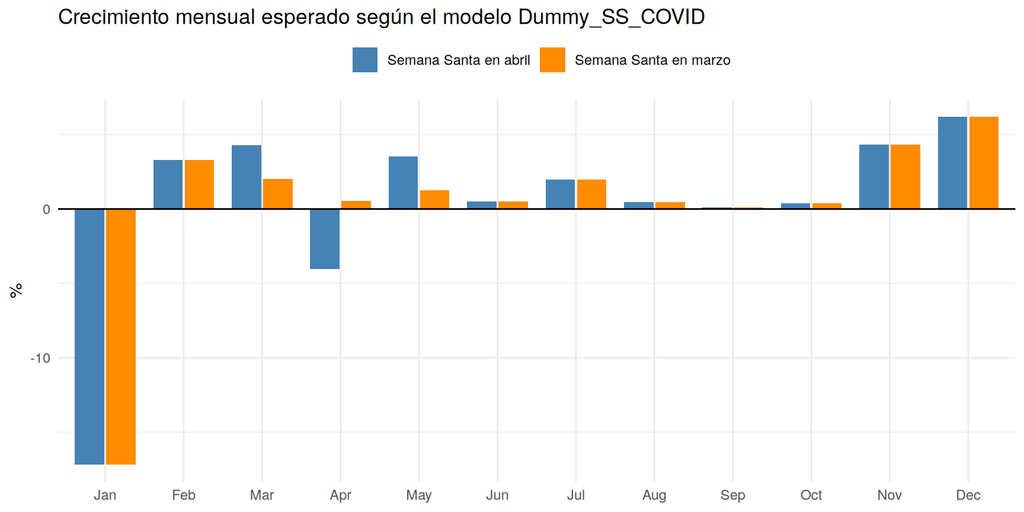

```r
## Crecimiento esperado de cada mes = intercepto (enero) + efecto del mes + efecto Semana Santa.
## Se calcula para los dos escenarios posibles de Semana Santa, sin pandemia.
b0 <- coefs$estimate[coefs$term == "(Intercept)"]
b_ss <- coefs$estimate[coefs$term == "d_ss"]

efectos <- coefs |>
  filter(str_detect(term, "season")) |>
  mutate(mes_num = as.integer(str_extract(term, "\\d+$"))) |>
  select(mes_num, estimate) |>
  add_row(mes_num = 1, estimate = 0) |>
  arrange(mes_num)

escenarios <- bind_rows(
  efectos |> mutate(escenario = "Semana Santa en abril",
                    d_ss = case_when(mes_num == 4 ~ 1, mes_num == 5 ~ -1, TRUE ~ 0)),
  efectos |> mutate(escenario = "Semana Santa en marzo",
                    d_ss = case_when(mes_num == 3 ~ 1, mes_num == 4 ~ -1, TRUE ~ 0))
) |>
  mutate(mes = factor(month.abb[mes_num], levels = month.abb),
         crec_esperado = 100 * (b0 + estimate + b_ss * d_ss))

ggplot(escenarios, aes(mes, crec_esperado, fill = escenario)) +
  geom_col(position = position_dodge(width = 0.8), width = 0.75) +
  geom_hline(yintercept = 0) +
  scale_fill_manual(values = c("Semana Santa en abril" = "steelblue",
                               "Semana Santa en marzo" = "darkorange")) +
  labs(title = "Crecimiento mensual esperado según el modelo Dummy_SS_COVID",
       x = NULL, y = "%", fill = NULL) +
  theme_minimal() + theme(legend.position = "top")
```

**Ver código**

```r
escenarios |>
  select(mes, escenario, crec_esperado) |>
  pivot_wider(names_from = escenario, values_from = crec_esperado) |>
  mutate(across(-mes, ~ round(.x, 2)))
```

```
# A tibble: 12 × 3
   mes   `Semana Santa en abril` `Semana Santa en marzo`
   <fct>                   <dbl>                   <dbl>
 1 Jan                    -17.2                   -17.2
 2 Feb                      3.28                    3.28
 3 Mar                      4.3                     2.02
 4 Apr                     -4.02                    0.53
 5 May                      3.52                    1.25
 6 Jun                      0.51                    0.51
 7 Jul                      1.99                    1.99
 8 Aug                      0.47                    0.47
 9 Sep                      0.12                    0.12
10 Oct                      0.37                    0.37
11 Nov                      4.32                    4.32
12 Dec                      6.2                     6.2
```

El modelo reproduce el patrón descrito: enero cae 17,2 % frente a diciembre, y noviembre y diciembre son los meses de mayor crecimiento. El coeficiente de `d_ss` es -0,0228: el mes que concentra los festivos de Semana Santa crece 2,3 puntos porcentuales menos, y el mes siguiente los recupera. Los pulsos de la pandemia recogen la caída de marzo (-11,1 pp) y abril de 2020 (-15,1 pp) frente a lo esperado, y la recuperación parcial de mayo a julio.

## 8.6 Diagnóstico de los residuales

**Ver código**

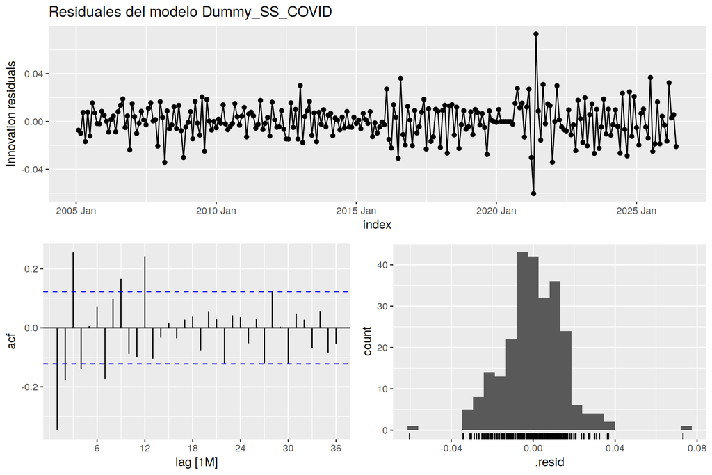

```r
modelo_final |> gg_tsresiduals(lag_max = 36) +
  labs(title = "Residuales del modelo Dummy_SS_COVID")
```

**Ver código**

```r
augment(modelo_final) |> features(.innov, ljung_box, lag = 24)
```

```
# A tibble: 1 × 3
  .model         lb_stat lb_pvalue
  <chr>            <dbl>     <dbl>
1 Dummy_SS_COVID    114.  1.25e-13
```

El modelo capta el patrón estacional determinístico, pero los residuales siguen autocorrelacionados: el ACF tiene valores significativos en los retardos 1, 3 y 12, y la prueba de Ljung-Box rechaza. Queda dependencia que no es estacionalidad fija: la de corto plazo y la parte estocástica de la estacionalidad vista antes. Esa estructura es la que se modelará después con ARMA/SARIMA. Los dos residuales más grandes corresponden a mayo de 2021 (caída) y junio de 2021 (rebote), meses del paro nacional; es otro episodio atípico a tener en cuenta en la etapa de modelamiento.

## 8.7 Desestacionalización

Para obtener la serie desestacionalizada se usa STL sobre log(ISE) con una ventana estacional de 13 años. A diferencia de la ventana `"periodic"` usada antes, esta permite que el patrón estacional cambie lentamente en el tiempo. Luego se vuelve a la escala original con la exponencial.

**Ver código**

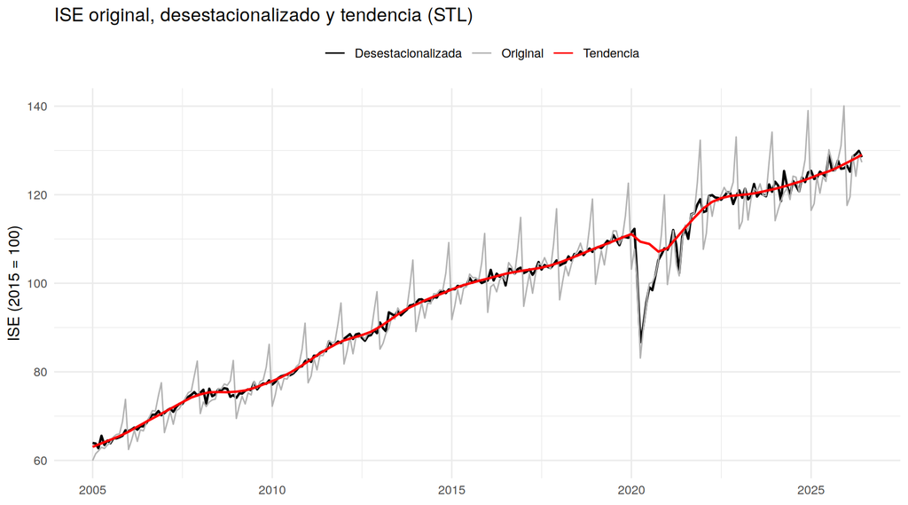

```r
stl_ise <- lise_tsbl |>
  model(STL(value ~ trend() + season(window = 13), robust = TRUE)) |>
  components()

ise_desest <- stl_ise |>
  mutate(Original = exp(value),
         Desestacionalizada = exp(season_adjust),
         Tendencia = exp(trend)) |>
  as_tibble() |>
  select(index, Original, Desestacionalizada, Tendencia) |>
  pivot_longer(-index, names_to = "serie", values_to = "valor")

ggplot(ise_desest, aes(as.Date(index), valor, color = serie)) +
  geom_line(aes(linewidth = serie)) +
  scale_color_manual(values = c(Original = "grey70", Desestacionalizada = "black", Tendencia = "red")) +
  scale_linewidth_manual(values = c(Original = 0.5, Desestacionalizada = 0.8, Tendencia = 0.8), guide = "none") +
  labs(title = "ISE original, desestacionalizado y tendencia (STL)",
       x = NULL, y = "ISE (2015 = 100)", color = NULL) +
  theme_minimal() + theme(legend.position = "top")
```

**Ver código**

```r
## Factor estacional promedio por mes: cuánto se desvía cada mes del nivel desestacionalizado
stl_ise |>
  as_tibble() |>
  mutate(mes = factor(month.abb[month(index)], levels = month.abb)) |>
  group_by(mes) |>
  summarise(factor_estacional_pct = round(100 * (exp(mean(season_year)) - 1), 2))
```

```
# A tibble: 12 × 2
   mes   factor_estacional_pct
   <fct>                 <dbl>
 1 Jan                   -6.84
 2 Feb                   -3.94
 3 Mar                   -0.54
 4 Apr                   -3.96
 5 May                   -0.77
 6 Jun                   -0.86
 7 Jul                    0.68
 8 Aug                    1.05
 9 Sep                    0.58
10 Oct                    0.34
11 Nov                    4.52
12 Dec                   10.8
```

La serie desestacionalizada deja ver con claridad la tendencia y los choques no estacionales, en particular la caída de 2020 y la recuperación posterior. Los factores estacionales resumen el patrón en la escala original: enero queda por debajo del nivel desestacionalizado y diciembre por encima, con diferencias del orden de 7 % y 11 %.

# 9 Conclusiones

1. **Gráfico.** El ISE tiene tendencia creciente, estacionalidad anual marcada (diciembre alto, enero bajo), varianza que crece con el nivel y un choque atípico entre marzo y julio de 2020.
2. **Box-Cox.** Se aplica el logaritmo. El método de Guerrero, la regla media-desviación y la verosimilitud perfil con tendencia flexible dan $\lambda$ cercano a cero una vez se controla por la pandemia, y el coeficiente de variación anual es estable alrededor de 5 %-6 %. La verosimilitud perfil con tendencia lineal da $\lambda = 1$ porque intenta enderezar una tendencia curva.
3. **Tendencia.** Una tendencia lineal en el logaritmo implica un crecimiento promedio de 3,2 % anual. La tendencia cúbica ajusta mejor y muestra la desaceleración: el crecimiento implícito pasa de 6,5 % anual en 2005 a cerca de 3 % desde 2015. Ninguna tendencia determinística captura la pandemia ni elimina la persistencia de los residuales. La primera diferencia sí lo hace, y las pruebas KPSS y ADF la respaldan.
4. **Dependencia.** Sobre la primera diferencia de log(ISE), la dependencia es negativa en los primeros retardos y muy alta en los retardos estacionales (12, 24, 36). La correlación de distancia supera al ACF en la serie completa, pero la diferencia desaparece al descontar las medias mensuales y el episodio de 2020: la dependencia es esencialmente lineal.
5. **Estacionalidad.** Todas las herramientas (mapa de calor, subseries, boxplots, periodograma y wavelets) muestran una estacionalidad anual estable durante toda la muestra, con un patrón abrupto que se refleja en armónicos fuertes (periodos de 2 a 6 meses). Existe además un efecto de Semana Santa que desplaza actividad entre marzo y abril, y el ACF sugiere un componente estacional estocástico.
6. **Modelamiento.** Los términos de Fourier necesitan $K = 6$ para ajustar bien, lo que equivale a las dummies. El mejor modelo combina dummies mensuales, el regresor de Semana Santa y pulsos para la pandemia. Sus residuales conservan autocorrelación, que deberá modelarse en la etapa ARMA/SARIMA, donde también se evaluará una diferencia estacional.